# A3: Incarceration

### Introduction

I am investigating the incarceration trends in racial populations over time. I will be considering all of the available races and the years of incarceration. I am choosing to analyze these because these rates are a deep history of America, and these societal problems have been prevalent in our lives ever since we were born, and longer. Many of our history classes cover these problems, of which are covered by the 13th Amendment documentary. I have watched this documentary multiple times for different classes, so finally being able to analyze the data myself helps give me a better scope on the issue.

For this investigation, I want to analyze this trend because in the news, I never see any headlines on any other race being incarcerated, other than those of black descent. Therefore, this investigation will help enlighten me to the idea that the media is only trying to highlight certain races, or if that is the reality of the prison system. An important thing to note is that I will be considering jail population, not prison population.

The variables in question, are:

- AAPI jail pop,
- Black jail pop,
- Latinx jail pop,
- Native jail pop,
- White jail pop,
- Total Jail pop,
- Year.

All of these are the different races considered, which are all valuable for my investigation. I can consider all of these trends and compare them over the years considered, to dive deeper into my analysis for the problem introduced.

### Summary Information

Interestingly, what has been discovered is that from 2018, the average counts for prison population rates across all counties are as follows: a AAPI jail population of **446.92**, a Black jail population of **2519.29**, a Latinx jail population of **972.74**, a Native jail population of **1046.69**, and a White jail population of **498.13**.

Across all these populations, currently the black jail population has the greatest rate, and the least being AAPI, followed closely by the white jail population. Overtime, however, it has seemed that there have been changes opposite to those conveyed by the currently jail population. As of recent, there has been some changes in the overall jailing populations. as of 2018 from 1990, there have been these following changes in population rates: in AAPI, there has been a change of **226.78**, in Black people, there has been a change of **-1521.59**, in Latinx, there has been a change of **219.24**, in Native, there has been a change of **606.37**, in White, there has been a change of **353.48**.

All of these changes illuminate how every race but black has been increasing in jailing, whereas the black jail population has been decreasing. These are also the mean values for all of the most recent values in all counties for jail populations.

### The Dataset

Who collected the data?

- The Vera Institute collected this data.

How was the data collected or generated?

- This data was collected by merging data from the BJS National Corrections Reporting Program (NCRP), and the original jails dataset to produce a dataset based on incarceration and jails rates at the county level.

Why was the data collected?

- Vera collected the data because they wanted to understand multiple trends and contours with incarceration in the United States. This data set gives light to deeper understandings of high rates of incarcerations in certain locations within the US.

How many observations (rows) are in your data?

- I am using the ‘us-prison-jail-rates-1990.csv’ and ‘us-prison-jail-rates.csv’ data sets.
- us-prison-jail-rates.csv contains **153811** rows of data.
- us-prison-jail-rates-1990.csv contains **91031** rows of data.

How many features (columns) are in the data?

- us-prison-jail-rates.csv contains **23** columns of data.
- us-prison-jail-rates-1990.csv contains **23** columns of data.

What, if any, ethical questions or questions of power do you need to consider when working with this data?

- Possible questions arise about how data is used. The findings, and extraction of data could be used differently by other people, and could potentially mean harm to marginalized groups of people.
- Another question that arises is how confidential the information is, and whether or not this data could be used for any decisions in the future, such as in politics, or other locations of policy making.

What are possible limitations or problems with this data?

Possible limitations of this data are that it doesn’t consider people individually. As in today’s world, we have seen many cases of where many people are falsely incarcerated, and for other reasons that should not be properly considered for incarceration. This data set does not consider any of that information, and only considers people in the data set as numbers. One of my lectures in my Anthropology and Sport class contains ethical concerns about viewing athletes as just numbers, and having an emotional connection to the athlete because of how they are only considered as a statistic.

This data set is extremely similar to that logic, as the people are only considered as mere numbers, rather than names and reason (although that starts to fit more into an ethical question!) would give us a greater scope of the reasoning and could find a cause and more data for locations and reason for incarceration. Without this data, however, it becomes hard to categorize the actual crimes and incarceration, because it doesn’t consider who the person was or what they were doing at the time of incarceration.

Another issue with the data is that it doesn’t consider by month, it only considers per year, which is enough to question the months that are incarcerated more commonly, and whether or not there is a trend with that information.

### Trends Over Time Chart

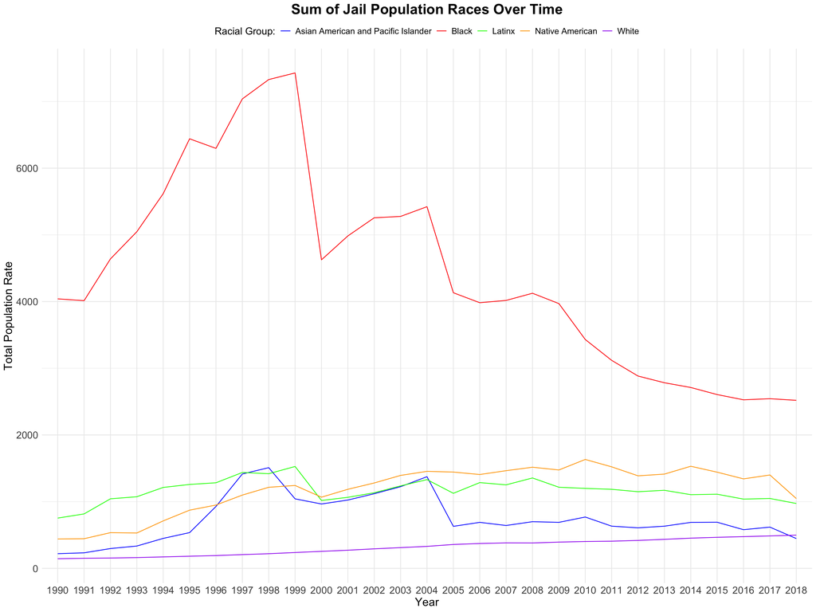

The only population that has been steadily increasing in jail rate since the start of data collection is the White population, however, every other population has been increasing or decreasing throughout the time period. This chart is a great visualization of how we can see some normalization of society, including treating races as equal, however we can see by the end of 2018 that this is still not truly the case.

### Variable Comparison Chart

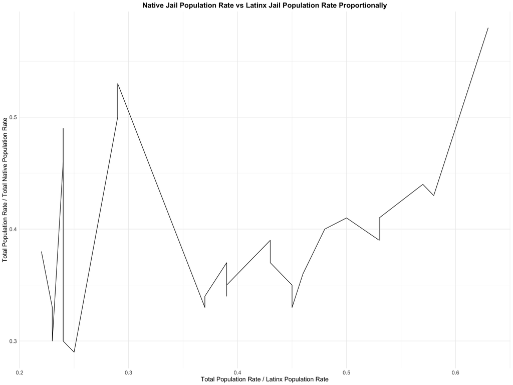

I included this variable comparison chart because I thought that comparing two different jail rates between two different races might highlight a correlation between the increases of both. After looking at this chart, it is very hard to determine any outcome as although the variables do increase with each other, there are so many dips in the data that no actual outcome can be determined.

I decided to find the average of all the population rates in one given year, then divide the total by each of the given race populations in jail. Interestingly enough, the total population rate is always less than than one given race, which inherently, doesn’t make very much sense. This data concludes that there could potentially be a reason between Native populations in jail increasing with Latinx populations in jail, but not enough evidence to properly make this conclusion.

In the time chart, I thought these two variables might have some correlation together. As one increased, the other increased, and I wanted to see how this could look on a graph.

### Map

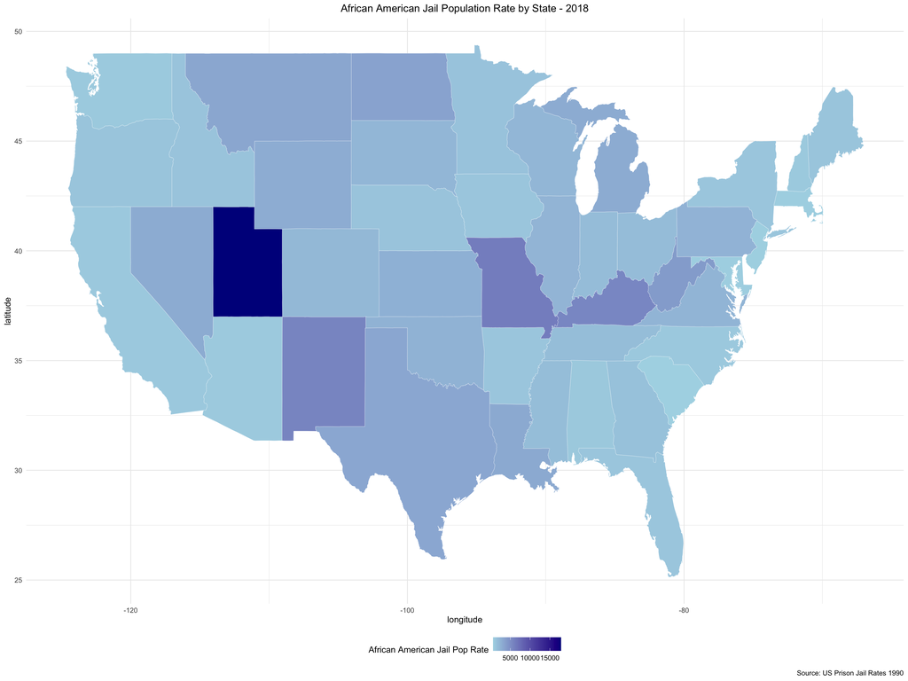

I created a chart based on the African American average jail population rate for each state. I included this chart because rather on a time chart by year, this makes it easier to visualize which states are having these large population rates in jail, and which are not. Interestingly, we see the darker shaded states to be more commonly having higher population rates in jail to be usually republican states, and lighter to be democratic states.

Interestingly enough, we see that Utah has the highest African American jail population rate. This is because of either the data for Utah being messed up, or the counties having different ways of counting populations.

Keep in mind that some states did not have data, such as Vermont, Connecticut and Delaware, which are not included on the map as they do not have any relevant information. This data is taken from the most recent value of data, and in the future if needed to be expanded, a new map could be created each year with the data and find color differences in the map.